# coeff of variation

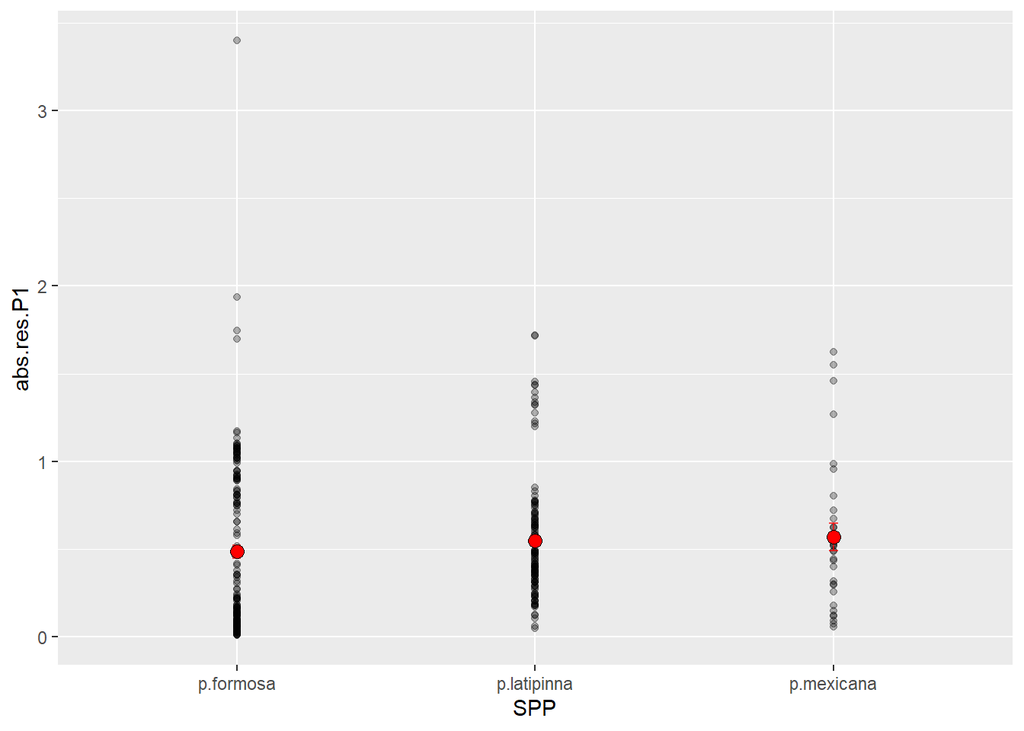

```r
ggplot(raw2, aes(SPP, abs.res.P1)) +
  geom_point(alpha=0.3) +
  stat_summary(fun.data=function(x){mean_cl_normal(x, conf.int=.683)}, geom="errorbar",
               width=0.03, colour="red", alpha=0.7) +
  stat_summary(fun=mean, geom="point", fill="red", pch=21, size=3)
```

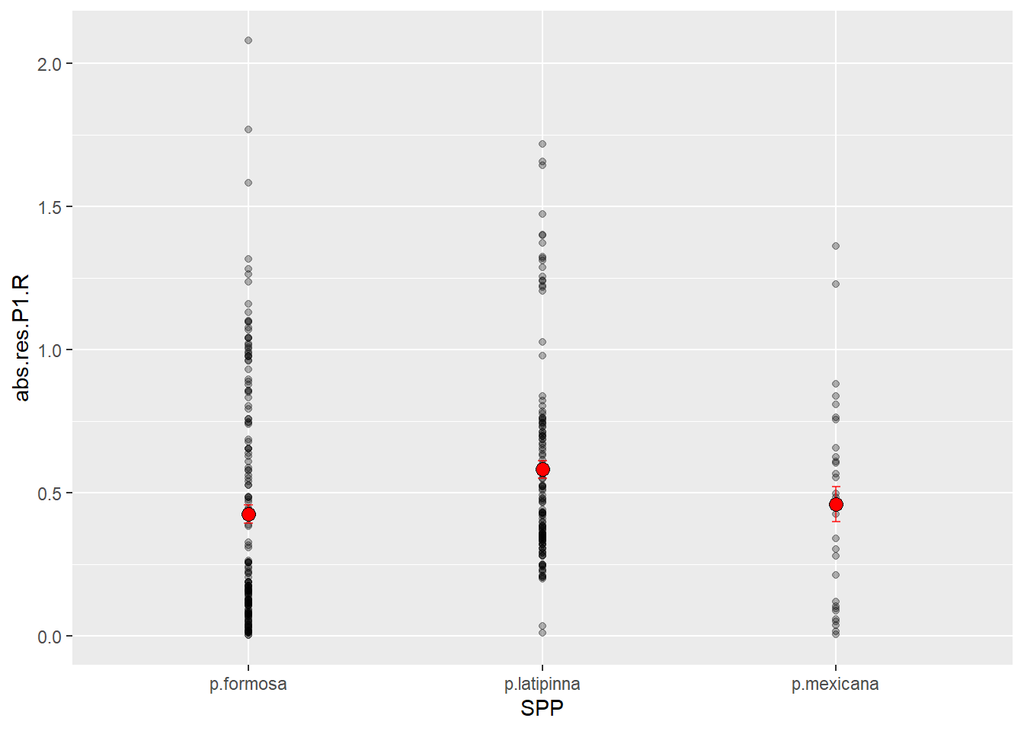

```r
ggplot(raw2, aes(SPP, abs.res.P1.R)) +
  geom_point(alpha=0.3) +
  stat_summary(fun.data=function(x){mean_cl_normal(x, conf.int=.683)}, geom="errorbar",
               width=0.03, colour="red", alpha=0.7) +
  stat_summary(fun=mean, geom="point", fill="red", pch=21, size=3)
```

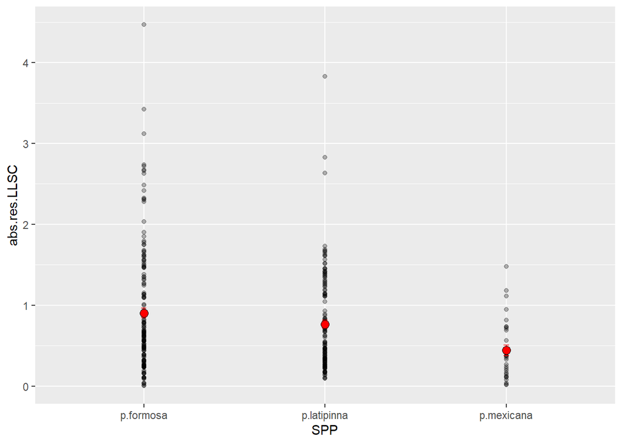

```r
ggplot(raw2, aes(SPP, abs.res.LLSC)) +
  geom_point(alpha=0.3) +
  stat_summary(fun.data=function(x){mean_cl_normal(x, conf.int=.683)}, geom="errorbar",
               width=0.03, colour="red", alpha=0.7) +
  stat_summary(fun=mean, geom="point", fill="red", pch=21, size=3)
```

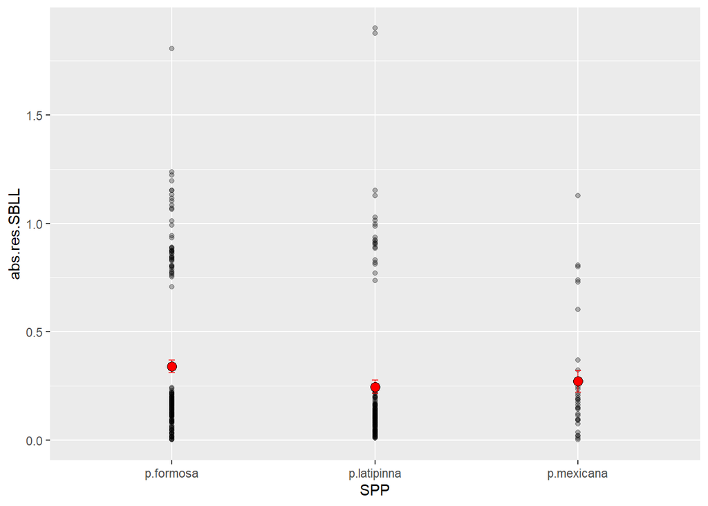

```r
ggplot(raw2, aes(SPP, abs.res.SBLL)) +
  geom_point(alpha=0.3) +
  stat_summary(fun.data=function(x){mean_cl_normal(x, conf.int=.683)}, geom="errorbar",
               width=0.03, colour="red", alpha=0.7) +
  stat_summary(fun=mean, geom="point", fill="red", pch=21, size=3)
```

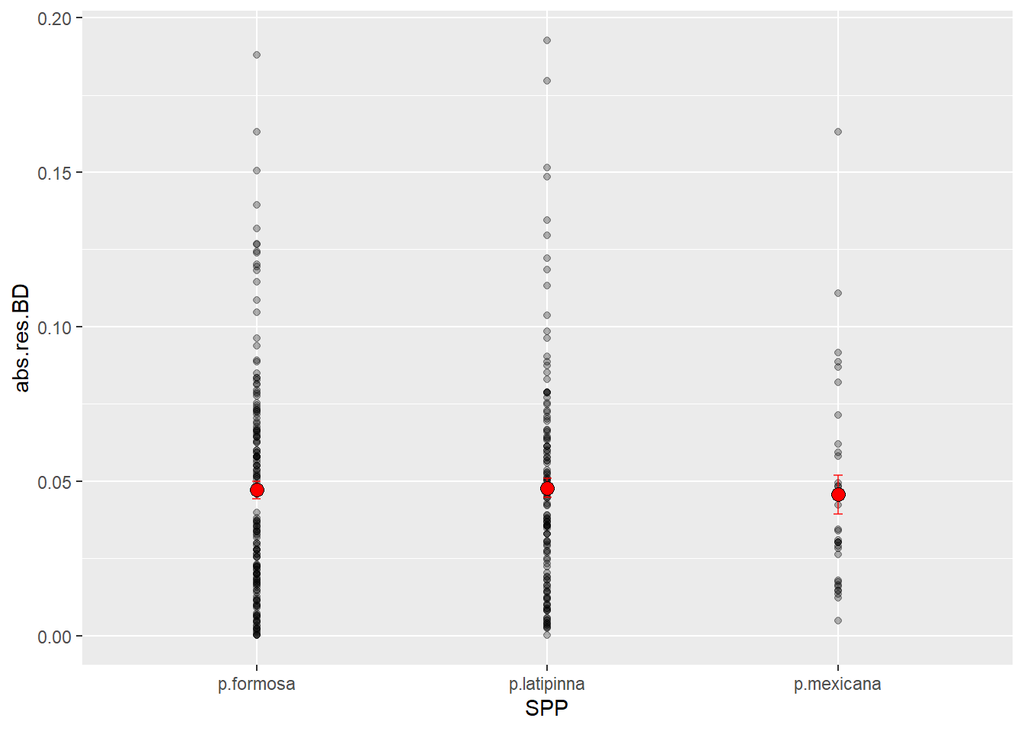

```r
ggplot(raw2, aes(SPP, abs.res.BD)) +
  geom_point(alpha=0.3) +
  stat_summary(fun.data=function(x){mean_cl_normal(x, conf.int=.683)}, geom="errorbar",
               width=0.03, colour="red", alpha=0.7) +
  stat_summary(fun=mean, geom="point", fill="red", pch=21, size=3)
```

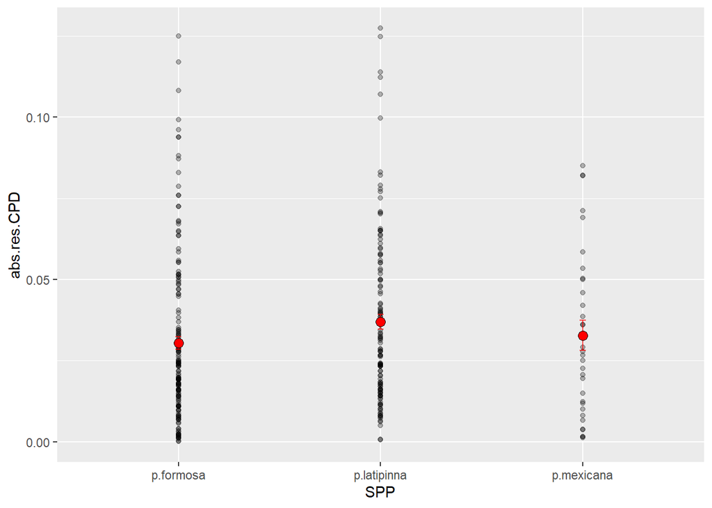

```r
ggplot(raw2, aes(SPP, abs.res.CPD)) +
  geom_point(alpha=0.3) +
  stat_summary(fun.data=function(x){mean_cl_normal(x, conf.int=.683)}, geom="errorbar",
               width=0.03, colour="red", alpha=0.7) +
  stat_summary(fun=mean, geom="point", fill="red", pch=21, size=3)
```

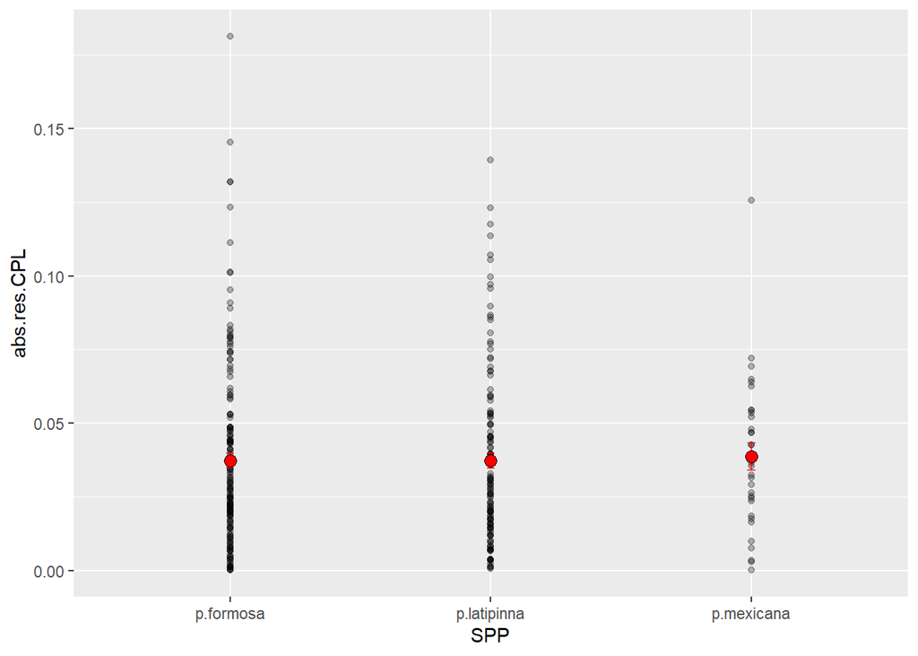

```r
ggplot(raw2, aes(SPP, abs.res.CPL)) +
  geom_point(alpha=0.3) +
  stat_summary(fun.data=function(x){mean_cl_normal(x, conf.int=.683)}, geom="errorbar",
               width=0.03, colour="red", alpha=0.7) +
  stat_summary(fun=mean, geom="point", fill="red", pch=21, size=3)
```

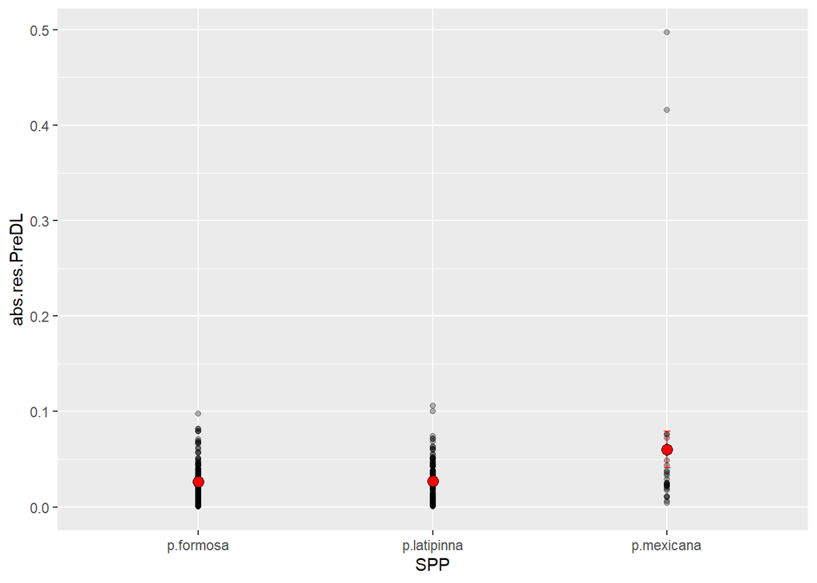

```r
ggplot(raw2, aes(SPP, abs.res.PreDL)) +
  geom_point(alpha=0.3) +
  stat_summary(fun.data=function(x){mean_cl_normal(x, conf.int=.683)}, geom="errorbar",
               width=0.03, colour="red", alpha=0.7) +
  stat_summary(fun=mean, geom="point", fill="red", pch=21, size=3)
```

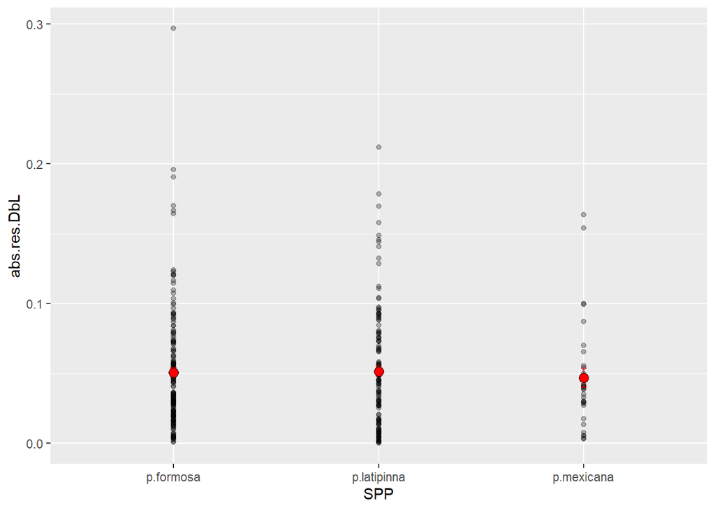

```r
ggplot(raw2, aes(SPP, abs.res.DbL)) +
  geom_point(alpha=0.3) +
  stat_summary(fun.data=function(x){mean_cl_normal(x, conf.int=.683)}, geom="errorbar",
               width=0.03, colour="red", alpha=0.7) +
  stat_summary(fun=mean, geom="point", fill="red", pch=21, size=3)
```

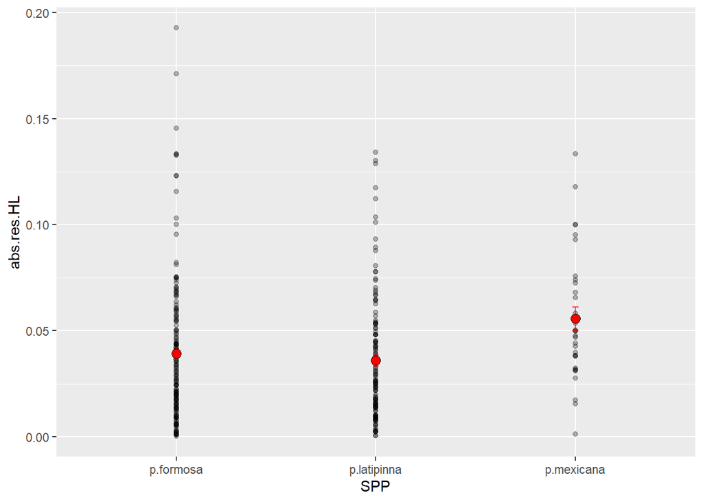

```r
ggplot(raw2, aes(SPP, abs.res.HL)) +
  geom_point(alpha=0.3) +
  stat_summary(fun.data=function(x){mean_cl_normal(x, conf.int=.683)}, geom="errorbar",
               width=0.03, colour="red", alpha=0.7) +
  stat_summary(fun=mean, geom="point", fill="red", pch=21, size=3)
```

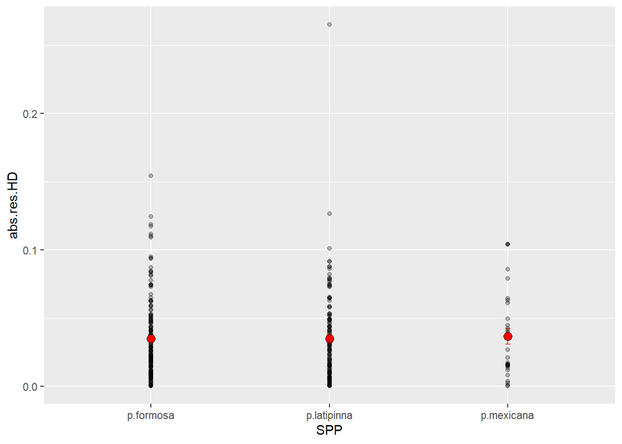

```r
ggplot(raw2, aes(SPP, abs.res.HD)) +
  geom_point(alpha=0.3) +
  stat_summary(fun.data=function(x){mean_cl_normal(x, conf.int=.683)}, geom="errorbar",
               width=0.03, colour="red", alpha=0.7) +
  stat_summary(fun=mean, geom="point", fill="red", pch=21, size=3)
```

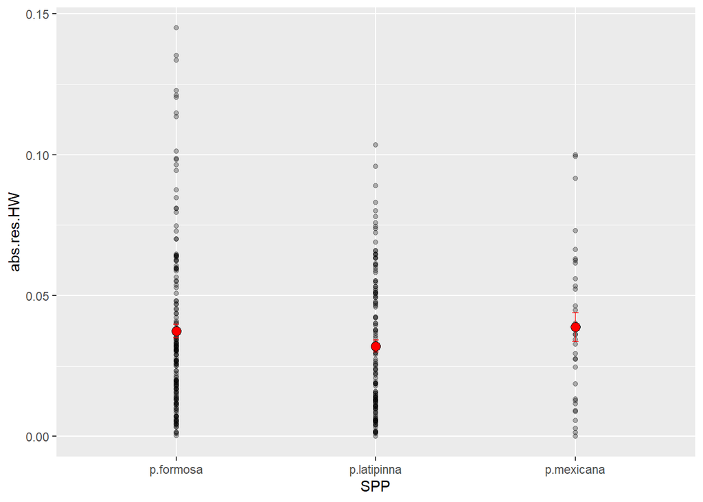

```r
ggplot(raw2, aes(SPP, abs.res.HW)) +
  geom_point(alpha=0.3) +
  stat_summary(fun.data=function(x){mean_cl_normal(x, conf.int=.683)}, geom="errorbar",
               width=0.03, colour="red", alpha=0.7) +
  stat_summary(fun=mean, geom="point", fill="red", pch=21, size=3)
```

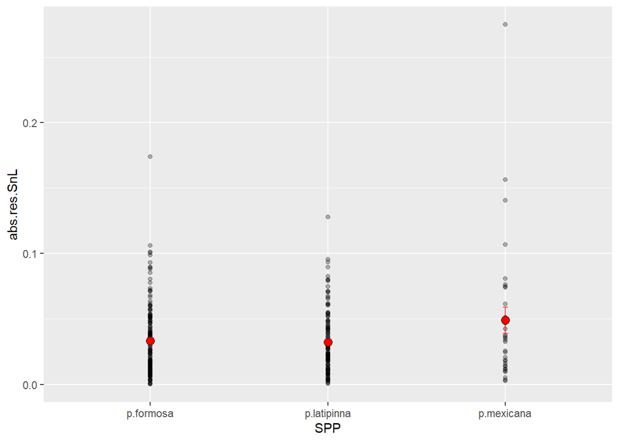

```r
ggplot(raw2, aes(SPP, abs.res.SnL)) +
  geom_point(alpha=0.3) +
  stat_summary(fun.data=function(x){mean_cl_normal(x, conf.int=.683)}, geom="errorbar",
               width=0.03, colour="red", alpha=0.7) +
  stat_summary(fun=mean, geom="point", fill="red", pch=21, size=3)
```

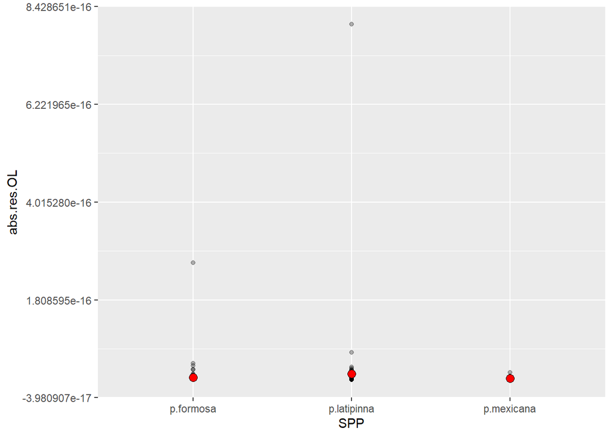

```r
ggplot(raw2, aes(SPP, abs.res.OL)) +
  geom_point(alpha=0.3) +
  stat_summary(fun.data=function(x){mean_cl_normal(x, conf.int=.683)}, geom="errorbar",
               width=0.03, colour="red", alpha=0.7) +
  stat_summary(fun=mean, geom="point", fill="red", pch=21, size=3)
```

# Comparing variation

## Variance tests

1. t-test for residuals, continuous
2. residual discrete will go through glmer
3. raw discrete will go through f-test (no idea how to do this otherwise), and results will be compared to visualizations to check for discrepencies.

F-test on residuals doesn’t make much sense; the residuals themselves are representative of the variation present, as they are the distance from the mean. Therefore, F-test on residuals is like variance of the variance. Instead, I have to do a t-test on the absolute value of the residuals. In this sense, we want to see if the mean of the absolute residuals is higher or lower for asexual species–is the average amount of variation higher or lower for this trait? Based on the regressions, if the trait was influenced by body size, I will perform a t-test on the absolute value of the residuals. If the trait was not influenced by body size, I will perform an F-test of variance on the raw data.

```
-   will do two-tailed and check out the residual means to infer direction; for traits in which we use raw data, a one-tailed f-test will be perfomed in both direction to determine which species is varying more. We will also visulize the variation using a histogram to confirm direction results.
```

### (1) Continuous, residuals

- will do two-tailed and check out the means to infer direction (see beginning for trait means w/o body correction)
- this will be for the traits that *did* have a significant regression compared to SL; will be using the absolute value residuals.
- For continuous traits, we will be using the transformed data.

#### T-tests

```
##
##  Welch Two Sample t-test
##
## data:  abs.lat.BD and abs.form.BD
## t = 0.16042, df = 287.17, p-value = 0.8727
## alternative hypothesis: true difference in means is not equal to 0
## 95 percent confidence interval:
##  -0.007699582  0.009066010
## sample estimates:
##  mean of x  mean of y
## 0.04778326 0.04710005
```

```
##
##  Welch Two Sample t-test
##
## data:  abs.lat.CPD and abs.form.CPD
## t = 2.1468, df = 282.5, p-value = 0.03266
## alternative hypothesis: true difference in means is not equal to 0
## 95 percent confidence interval:
##  0.0005394989 0.0124439196
## sample estimates:
##  mean of x  mean of y
## 0.03695739 0.03046568
```

```
##
##  Welch Two Sample t-test
##
## data:  abs.lat.CPD and abs.form.CPD
## t = 2.1468, df = 282.5, p-value = 0.01633
## alternative hypothesis: true difference in means is greater than 0
## 95 percent confidence interval:
##  0.001501493         Inf
## sample estimates:
##  mean of x  mean of y
## 0.03695739 0.03046568
```

```
##
##  Welch Two Sample t-test
##
## data:  abs.lat.CPD and abs.form.CPD
## t = 2.1468, df = 282.5, p-value = 0.9837
## alternative hypothesis: true difference in means is less than 0
## 95 percent confidence interval:
##        -Inf 0.01148193
## sample estimates:
##  mean of x  mean of y
## 0.03695739 0.03046568
```

```
##
##  Welch Two Sample t-test
##
## data:  abs.lat.CPL and abs.form.CPL
## t = -0.015652, df = 291.31, p-value = 0.9875
## alternative hypothesis: true difference in means is not equal to 0
## 95 percent confidence interval:
##  -0.007002590  0.006892088
## sample estimates:
##  mean of x  mean of y
## 0.03732998 0.03738523
```

```
##
##  Welch Two Sample t-test
##
## data:  abs.lat.PreDL and abs.form.PreDL
## t = 0.37319, df = 279.25, p-value = 0.7093
## alternative hypothesis: true difference in means is not equal to 0
## 95 percent confidence interval:
##  -0.003813117  0.005597125
## sample estimates:
##  mean of x  mean of y
## 0.02707836 0.02618636
```

```
##
##  Welch Two Sample t-test
##
## data:  abs.lat.DbL and abs.form.DbL
## t = 0.19254, df = 284.63, p-value = 0.8475
## alternative hypothesis: true difference in means is not equal to 0
## 95 percent confidence interval:
##  -0.00883155  0.01074664
## sample estimates:
##  mean of x  mean of y
## 0.05163660 0.05067905
```

```
##
##  Welch Two Sample t-test
##
## data:  abs.lat.HL and abs.form.HL
## t = -0.90175, df = 296.34, p-value = 0.3679
## alternative hypothesis: true difference in means is not equal to 0
## 95 percent confidence interval:
##  -0.010530987  0.003912795
## sample estimates:
##  mean of x  mean of y
## 0.03588147 0.03919057
```

```
##
##  Welch Two Sample t-test
##
## data:  abs.lat.HD and abs.form.HD
## t = -0.00099329, df = 267.38, p-value = 0.9992
## alternative hypothesis: true difference in means is not equal to 0
## 95 percent confidence interval:
##  -0.007275651  0.007268313
## sample estimates:
##  mean of x  mean of y
## 0.03506907 0.03507274
```

```
##
##  Welch Two Sample t-test
##
## data:  abs.lat.HW and abs.form.HW
## t = -1.6871, df = 297.98, p-value = 0.09263
## alternative hypothesis: true difference in means is not equal to 0
## 95 percent confidence interval:
##  -0.0116134871  0.0008923157
## sample estimates:
##  mean of x  mean of y
## 0.03208151 0.03744209
```

```
##
##  Welch Two Sample t-test
##
## data:  abs.lat.SnL and abs.form.SnL
## t = -0.38886, df = 295.99, p-value = 0.6977
## alternative hypothesis: true difference in means is not equal to 0
## 95 percent confidence interval:
##  -0.006851803  0.004590862
## sample estimates:
##  mean of x  mean of y
## 0.03208694 0.03321741
```

```
##
##  Welch Two Sample t-test
##
## data:  abs.lat.OL and abs.form.OL
## t = 1.318, df = 152.51, p-value = 0.1895
## alternative hypothesis: true difference in means is not equal to 0
## 95 percent confidence interval:
##  -4.062607e-18  2.034670e-17
## sample estimates:
##    mean of x    mean of y
## 1.416081e-17 6.018764e-18
```

### (2) Discrete, residuals

Logan suggested doing a glm with poisson distribution (because it is count data) for these relationships.

Had to remove the poisson part, because the residuals didn’t meet the non-integer requirement for poisson (it freaked out and took forever to load).

#### GLMs

```r
raw3 <- raw2[raw2$SPP !="p.mexicana", ]

glm_D <- glm(abs.res.D~SPP, data=raw3)
print(summary(glm_D), show.residuals=TRUE)
```

```
##
## Call:
## glm(formula = abs.res.D ~ SPP, data = raw3)
##
## Deviance Residuals:
##     Min       1Q   Median       3Q      Max
## -0.5474  -0.3920  -0.1006   0.3170   1.6061
##
## Coefficients:
##                Estimate Std. Error t value Pr(>|t|)
## (Intercept)     0.56682    0.03151  17.989   <2e-16 ***
## SPPp.latipinna -0.02927    0.04715  -0.621    0.535
## ---
## Signif. codes:  0 '***' 0.001 '**' 0.01 '*' 0.05 '.' 0.1 ' ' 1
##
## (Dispersion parameter for gaussian family taken to be 0.1648051)
##
##     Null deviance: 49.175  on 299  degrees of freedom
## Residual deviance: 49.112  on 298  degrees of freedom
## AIC: 314.46
##
## Number of Fisher Scoring iterations: 2
```

```r
D.aov <- aov(glm_D)
summary(D.aov)
```

```
##              Df Sum Sq Mean Sq F value Pr(>F)
## SPP           1   0.06 0.06351   0.385  0.535
## Residuals   298  49.11 0.16481
```

```r
glm_P1 <- glm(abs.res.P1~SPP, data=raw3)
print(summary(glm_P1), show.residuals=TRUE)
```

```
##
## Call:
## glm(formula = abs.res.P1 ~ SPP, data = raw3)
##
## Deviance Residuals:
##     Min       1Q   Median       3Q      Max
## -0.5006  -0.3420  -0.1328   0.2626   2.9146
##
## Coefficients:
##                Estimate Std. Error t value Pr(>|t|)
## (Intercept)     0.48436    0.03362  14.406   <2e-16 ***
## SPPp.latipinna  0.06231    0.05031   1.238    0.217
## ---
## Signif. codes:  0 '***' 0.001 '**' 0.01 '*' 0.05 '.' 0.1 ' ' 1
##
## (Dispersion parameter for gaussian family taken to be 0.1876585)
##
##     Null deviance: 56.210  on 299  degrees of freedom
## Residual deviance: 55.922  on 298  degrees of freedom
## AIC: 353.42
##
## Number of Fisher Scoring iterations: 2
```

```r
P1.aov <- aov(glm_P1)
summary(P1.aov)
```

```
##              Df Sum Sq Mean Sq F value Pr(>F)
## SPP           1   0.29  0.2878   1.534  0.217
## Residuals   298  55.92  0.1877
```

```r
glm_P1.R <- glm(abs.res.P1.R~SPP, data=raw3)
print(summary(glm_P1.R), show.residuals=TRUE)
```

```
##
## Call:
## glm(formula = abs.res.P1.R ~ SPP, data = raw3)
##
## Deviance Residuals:
##     Min       1Q   Median       3Q      Max
## -0.5705  -0.2933  -0.1676   0.1833   1.6538
##
## Coefficients:
##                Estimate Std. Error t value Pr(>|t|)
## (Intercept)     0.42420    0.03055  13.887  < 2e-16 ***
## SPPp.latipinna  0.15574    0.04571   3.407 0.000746 ***
## ---
## Signif. codes:  0 '***' 0.001 '**' 0.01 '*' 0.05 '.' 0.1 ' ' 1
##
## (Dispersion parameter for gaussian family taken to be 0.1548898)
##
##     Null deviance: 47.955  on 299  degrees of freedom
## Residual deviance: 46.157  on 298  degrees of freedom
## AIC: 295.84
##
## Number of Fisher Scoring iterations: 2
```

```r
P1.R.aov <- aov(glm_P1.R)
summary(P1.R.aov)
```

```
##              Df Sum Sq Mean Sq F value   Pr(>F)
## SPP           1   1.80  1.7983   11.61 0.000746 ***
## Residuals   298  46.16  0.1549
## ---
## Signif. codes:  0 '***' 0.001 '**' 0.01 '*' 0.05 '.' 0.1 ' ' 1
```

```r
glm_LLSC <- glm(abs.res.LLSC~SPP, data=raw3)
print(summary(glm_LLSC), show.residuals=TRUE)
```

```
##
## Call:
## glm(formula = abs.res.LLSC ~ SPP, data = raw3)
##
## Deviance Residuals:
##     Min       1Q   Median       3Q      Max
## -0.9022  -0.4792  -0.2428   0.4210   3.5649
##
## Coefficients:
##                Estimate Std. Error t value Pr(>|t|)
## (Intercept)     0.90388    0.05395  16.755   <2e-16 ***
## SPPp.latipinna -0.13748    0.08072  -1.703   0.0896 .
## ---
## Signif. codes:  0 '***' 0.001 '**' 0.01 '*' 0.05 '.' 0.1 ' ' 1
##
## (Dispersion parameter for gaussian family taken to be 0.4830762)
##
##     Null deviance: 145.36  on 299  degrees of freedom
## Residual deviance: 143.96  on 298  degrees of freedom
## AIC: 637.08
##
## Number of Fisher Scoring iterations: 2
```

```r
LLSC.aov <- aov(glm_LLSC)
summary(LLSC.aov)
```

```
##              Df Sum Sq Mean Sq F value Pr(>F)
## SPP           1    1.4  1.4013   2.901 0.0896 .
## Residuals   298  144.0  0.4831
## ---
## Signif. codes:  0 '***' 0.001 '**' 0.01 '*' 0.05 '.' 0.1 ' ' 1
```

### (3) Discrete, raw

This will only be for the traits that did **not** have a significant regression compared to SL (so P2s, A, SALL, SBDF, and FLA); none of these traits were transformed, so just doing raw for now.

#### Levene’s test

Still only performing this on the traits that did **NOT** vary with SL (P2L/R, A, SALL, SBLL [between sail and amz only], SBDF, FLA).

```r
library(car)
library(carData)

(LT_P2L <- leveneTest(P2.L~SPP, data=raw3)) #gives nothing since it's all the same value
```

```
## Levene's Test for Homogeneity of Variance (center = median)
##        Df F value Pr(>F)
## group   1     NaN    NaN
##       298
```

```r
(LT_P2R <- leveneTest(P2.R~SPP, data=raw3)) #same as above
```

```
## Levene's Test for Homogeneity of Variance (center = median)
##        Df F value Pr(>F)
## group   1     NaN    NaN
##       298
```

```r
(LT_A <- leveneTest(A~SPP, data=raw3))
```

```
## Levene's Test for Homogeneity of Variance (center = median)
##        Df F value Pr(>F)
## group   1  0.3962 0.5295
##       298
```

```r
(LT_SALL <- leveneTest(SALL~SPP, data=raw3))
```

```
## Levene's Test for Homogeneity of Variance (center = median)
##        Df F value  Pr(>F)
## group   1  3.7062 0.05516 .
##       298
## ---
## Signif. codes:  0 '***' 0.001 '**' 0.01 '*' 0.05 '.' 0.1 ' ' 1
```

```r
(LT_SBLL <- leveneTest(SBLL~SPP, data=raw3))
```

```
## Levene's Test for Homogeneity of Variance (center = median)
##        Df F value Pr(>F)
## group   1    3.36 0.0678 .
##       298
## ---
## Signif. codes:  0 '***' 0.001 '**' 0.01 '*' 0.05 '.' 0.1 ' ' 1
```

```r
(LT_SBDF <- leveneTest(SBDF~SPP, data=raw3))
```

```
## Levene's Test for Homogeneity of Variance (center = median)
##        Df F value Pr(>F)
## group   1  0.0081 0.9283
##       298
```

```r
(LT_FLA <- leveneTest(FLA~SPP, data=raw3))
```

```
## Levene's Test for Homogeneity of Variance (center = median)
##        Df F value Pr(>F)
## group   1  2.7164 0.1004
##       298
```

# PCA analysis

## PCA

LOGAN: CHECK THAT EACH VARIABLES IS NEAR NORMALLY DISTRIBUTED. IF NOT, LOG TRANSFORM BEFORE PCA. ALSO CHECK THAT PCA CALCULATES Z SCORES AND PLOTS BASED ON THAT; IF NOT CONVERT TO Z SCORES THEN RUN PCA.

### Chart

```r
(chart <- matrix(c("Variable chart:", "D: dorsal ray count", "P1: left pectoral ray count", "P2.R: right pelvic rays", "P2.L: left pelvic rays", "A: anal rays", "P1.R: right pectoral ray count", "LLSC: lateral line scale count", "SALL: scalesabove lateral line", "SBLL: scalesbelow lateral line", "SBDF: scalesbefore dorsal fin", "TL: total length", "SL: standard length", "BD: body depth", "CPD: caudal peduncle depth", "CPL: caudal peduncle length", "PreDL: pre-dorsal length", "DbL: dorsal base length", "HL/HW/HD: head length/width/depth", "SnL: snout length", "OL: ocular length"), ncol=1, byrow=TRUE))
```

```
##       [,1]
##  [1,] "Variable chart:"
##  [2,] "D: dorsal ray count"
##  [3,] "P1: left pectoral ray count"
##  [4,] "P2.R: right pelvic rays"
##  [5,] "P2.L: left pelvic rays"
##  [6,] "A: anal rays"
##  [7,] "P1.R: right pectoral ray count"
##  [8,] "LLSC: lateral line scale count"
##  [9,] "SALL: scalesabove lateral line"
## [10,] "SBLL: scalesbelow lateral line"
## [11,] "SBDF: scalesbefore dorsal fin"
## [12,] "TL: total length"
## [13,] "SL: standard length"
## [14,] "BD: body depth"
## [15,] "CPD: caudal peduncle depth"
## [16,] "CPL: caudal peduncle length"
## [17,] "PreDL: pre-dorsal length"
## [18,] "DbL: dorsal base length"
## [19,] "HL/HW/HD: head length/width/depth"
## [20,] "SnL: snout length"
## [21,] "OL: ocular length"
```

### Loadings

```r
library(stringr)

raw1a <- subset(raw1, select = -c(17:18) ) #took out P2R and L since they don't vary at all
raw1a <- subset(raw1a, select=-c(34:49))#took out transformed values
raw1a <- raw1a[raw1a$SPP !="p.mexicana", ]

#PCA <- prcomp(raw1a[, 15:32], center=TRUE, scale. = TRUE) #includes all but pelvic traits, since they are the same in all species WILL SCALE/CENTER DATA ON MY OWN, LOGAN SAID IT IS NOT ALWAYS DOING IT FOR YOU EVEN WHEN YOU SPECIFY

z.scores <- scale(raw1a[, 15:33], center = TRUE, scale = TRUE)

raw1a <- cbind(raw1a, z.scores)

colnames(raw1a)[34:52] <- str_c( "z_", colnames(raw1a)[15:33] )

PCA <- prcomp(raw1a[, 34:52])

summary(PCA)
```

```
## Importance of components:
##                           PC1    PC2     PC3     PC4     PC5     PC6     PC7
## Standard deviation     3.0628 1.6531 1.14425 1.03347 0.98389 0.92628 0.89325
## Proportion of Variance 0.4937 0.1438 0.06891 0.05621 0.05095 0.04516 0.04199
## Cumulative Proportion  0.4937 0.6375 0.70647 0.76268 0.81363 0.85879 0.90078
##                            PC8     PC9    PC10    PC11   PC12    PC13    PC14
## Standard deviation     0.63539 0.56651 0.54153 0.50391 0.4226 0.34766 0.30647
## Proportion of Variance 0.02125 0.01689 0.01543 0.01336 0.0094 0.00636 0.00494
## Cumulative Proportion  0.92203 0.93892 0.95435 0.96772 0.9771 0.98348 0.98842
##                           PC15    PC16    PC17    PC18    PC19
## Standard deviation     0.26119 0.22675 0.22086 0.20498 0.09759
## Proportion of Variance 0.00359 0.00271 0.00257 0.00221 0.00050
## Cumulative Proportion  0.99201 0.99472 0.99729 0.99950 1.00000
```

```r
(loadings <- PCA$rotation[, 1:5])
```

```
##                  PC1          PC2          PC3           PC4         PC5
## z_D     -0.023125918  0.512339587  0.274296565  0.1004003051  0.06565042
## z_P1    -0.021172287 -0.400745232  0.383033685  0.2535355028  0.01970006
## z_A     -0.002691019 -0.067691278  0.577547144  0.1247870940  0.17951684
## z_P1.R  -0.036159356 -0.424337470  0.298509581  0.3147900237  0.03199074
## z_LLSC  -0.080066865  0.274308397  0.251844804  0.0003399013 -0.31938239
## z_SALL  -0.050532616 -0.051296850 -0.486844238  0.6498672092  0.09308622
## z_SBLL  -0.057856335  0.108431193  0.058099357  0.3413704601 -0.82866776
## z_SBDF  -0.012995775 -0.409590786 -0.106164211 -0.3912320042 -0.38140946
## z_SL    -0.321020234 -0.055330649  0.006015599 -0.0470335950  0.01203157
## z_BD    -0.311442077  0.090305116 -0.004141675  0.0106665883  0.02609686
## z_CPD   -0.317091552 -0.007465525 -0.010294404 -0.0008030631  0.04637472
## z_CPL   -0.309216131 -0.069705738  0.021123514 -0.0006747957  0.02689966
## z_PreDL -0.299230116 -0.185161125 -0.042850750 -0.0702738205 -0.02769696
## z_DbL   -0.263082815  0.281326647  0.099848288  0.0405728383  0.07710593
## z_HL    -0.286373286 -0.053376922  0.070063685 -0.2068118584 -0.03298241
## z_HD    -0.311950929  0.025861089 -0.028257174 -0.0978219713  0.01977228
## z_HW    -0.312983506 -0.027005739 -0.102965431  0.0624696740  0.02652160
## z_SnL   -0.269756709 -0.018795144 -0.104316832  0.2067219100  0.08042476
## z_OL    -0.283210589  0.026602769  0.026187203 -0.1056545356 -0.01248445
```

```r
VM_PCA <- varimax(PCA$rotation[, 1:3])

VM_PCA
```

```
## $loadings
##
## Loadings:
##         PC1    PC2    PC3
## z_D             0.579
## z_P1           -0.170  0.526
## z_A             0.209  0.542
## z_P1.R         -0.228  0.463
## z_LLSC          0.368
## z_SALL         -0.263 -0.405
## z_SBLL          0.130
## z_SBDF         -0.406
## z_SL    -0.324
## z_BD    -0.298  0.120
## z_CPD   -0.316
## z_CPL   -0.313
## z_PreDL -0.321 -0.140
## z_DbL   -0.220  0.329
## z_HL    -0.285
## z_HD    -0.308
## z_HW    -0.321
## z_SnL   -0.277
## z_OL    -0.275
##
##                  PC1   PC2   PC3
## SS loadings    1.000 1.000 1.000
## Proportion Var 0.053 0.053 0.053
## Cumulative Var 0.053 0.105 0.158
##
## $rotmat
##            [,1]       [,2]        [,3]
## [1,] 0.99025106 -0.1389062 -0.01038808
## [2,] 0.11785093  0.8752334 -0.46912433
## [3,] 0.07425625  0.4633266  0.88307103
```

```r
library(factoextra)
(eig.val <- get_eigenvalue(PCA))
```

```
##         eigenvalue variance.percent cumulative.variance.percent
## Dim.1  9.380664534      49.37191860                    49.37192
## Dim.2  2.732862474      14.38348671                    63.75541
## Dim.3  1.309310206       6.89110635                    70.64651
## Dim.4  1.068052941       5.62133127                    76.26784
## Dim.5  0.968046113       5.09497954                    81.36282
## Dim.6  0.857998424       4.51578118                    85.87860
## Dim.7  0.797895874       4.19945197                    90.07806
## Dim.8  0.403714450       2.12481290                    92.20287
## Dim.9  0.320936708       1.68914057                    93.89201
## Dim.10 0.293253289       1.54343836                    95.43545
## Dim.11 0.253927815       1.33646218                    96.77191
## Dim.12 0.178592564       0.93996086                    97.71187
## Dim.13 0.120864150       0.63612710                    98.34800
## Dim.14 0.093923089       0.49433204                    98.84233
## Dim.15 0.068220281       0.35905411                    99.20138
## Dim.16 0.051415517       0.27060799                    99.47199
## Dim.17 0.048780881       0.25674148                    99.72873
## Dim.18 0.042016114       0.22113744                    99.94987
## Dim.19 0.009524576       0.05012935                   100.00000
```

```r
ind <- get_pca_ind(PCA)
head(ind$coord[,1:4])
```

```
##         Dim.1     Dim.2      Dim.3       Dim.4
## 1 -3.79218614 1.1636137  0.1800926 -0.08963595
## 2 -3.78917831 0.9596244  1.3893620 -2.02646387
## 3 -7.11228308 1.9828091 -0.7472805 -0.85903835
## 4  0.73532897 1.9695620 -1.5908193  0.72014647
## 5 -2.08118776 2.6499339 -0.3743038 -0.54991733
## 7  0.02419752 2.0659483 -1.8182757  1.04810458
```

```r
raw1.p <- raw1[raw1$SPP !="p.mexicana", ]
raw1.p <- cbind(raw1.p, ind$coord[,1:4])

lat.p <- raw1.p[raw1.p$SPP == "p.latipinna",]


form.p <- raw1.p[raw1.p$SPP == "p.formosa",]
```

### Plots

#### PCA 1v2

```r
library(AMR)
library(ggplot2)
library(ggfortify)
library(ggbiplot)
wes.yel <- "#E1AF00"
wes.blu <- "#78B7C5"

plot1<- autoplot(PCA, data = raw1a, colour="SPP", loadings=FALSE, loadings.label=FALSE, frame=TRUE, frame.type='norm')+scale_color_manual(values=c("#E1AF00","#78B7C5"))+ scale_fill_manual(values=c("#E1AF00","#78B7C5"))+ ggtitle("PCA Plot of Morphology traits") + theme_classic()
```

#### PCA 2v3

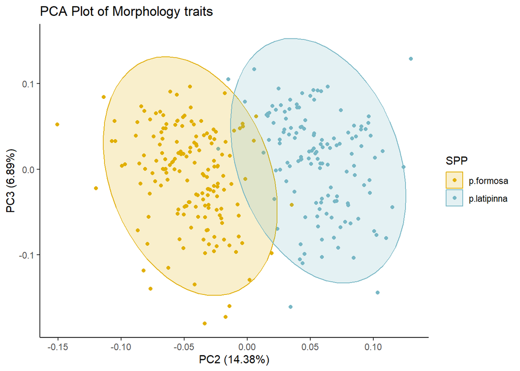

```r
plot5<- autoplot(PCA, x=2, y=3, data = raw1a, colour='SPP', loadings=FALSE, loadings.label=FALSE, frame=TRUE, frame.type='norm')+scale_color_manual(values=c("#E1AF00","#78B7C5"))+ scale_fill_manual(values=c("#E1AF00","#78B7C5"))+ ggtitle("PCA Plot of Morphology traits") + theme_classic()
plot5
```

# Coefficient of variation

Steve mentioned that using coefficient of variation would be able to distinguish adaptability of species across the range to local environments vs genetic drift. If CVs are similar across species then this would suggest adaptability, but if they are different then it’s genetic drift.

Since some of my data is raw, some is transformed, and some is corrected for body size, I will calculate a CV for each trait in those three forms (if applicable). Could also potentially take the PC loadings and use those (would have 3 CVs for this, for each of the important PCs). I am pretty sure (judging from morph-comparisons-final), that the pca was done on the z-scores of raw values, not transformed or residuals.

Doesn’t look like there is a particular function, just typing in mean and sd for the column you want. Might make my own function??

```r
coef_var <- function(x){
  sd(x)/mean(x)
}
```

Not 100% sure which coeff will be most useful (or correct) for comparison, so for right now, I will do all combinations and remove what is not useful/correct after discussing with Mike. Combinations include:

1. Amazon vs Sailfin, each trait, raw data
2. Amazon vs sailfin, each trait, size corrected data
3. Amazon vs sailfin, PC1 data
4. Amazon vs sailfin, PC2 data
5. Amazon vs sailfin, PC3 data
6. Amazon across zones, each trait, raw data
7. Amazon across zones, each trait, size corrected data
8. Amazon across zones, PC1 data
9. Amazon across zones, PC2 data
10. Amazon across zones, PC3 data
11. Sailfin across zones, each trait, raw data
12. Sailfin across zones, each trait, size corrected data
13. Sailfin across zones, PC1 data
14. Sailfin across zones, PC2 data
15. Sailfin across zones, PC3 data
16. Amazon across basins, each trait, raw data
17. Amazon across basins, each trait, size corrected data
18. Amazon across basins, PC1 data
19. Amazon across basins, PC2 data
20. Amazon across basins, PC3 data
21. Sailfin across basins, each trait, raw data
22. Sailfin across basins, each trait, size corrected data
23. Sailfin across basins, PC1 data
24. Sailfin across basins, PC2 data
25. Sailfin across basins, PC3 data

There are only 4 of the 7 basins that are shared between the species, so I will only do those 4. Additionally, only 4 of the 10 watersheds are shared between the species, so don’t think it’s a worthwhile comparison to make. Will stick with zones and basins.

## Combos 1-5

Amazon vs sailfin, each trait, raw, size corrected, and PCA data

*NOTE*: I’m not sure I can do all the traits by species for PCA data. I think I either get each individuals dimension for each PC axis (so would compare a single value for amz vs sailfin on PC1) OR I get the loadings for each trait, not separated by species. Going to go with the prior option, not sure if this is useful/correct.

```r
## separate species
rawA <- raw1[raw1$SPP == "p.formosa",]
rawA <- rawA[, -c(17:18)]

rawS <- raw1[raw1$SPP == "p.latipinna",]
rawS <- rawS[, -c(17:18)]

##Amazon, raw data
amz_cv1 <- lapply(rawA[15:34], coef_var)

##Sailfin, raw data
lat_cv1 <- lapply(rawS[15:34], coef_var)

###### Not sure, but will do the transformed data as well

## Amazon, transformed (only metric traits)
amz_cv1a <- lapply(rawA[35:49], coef_var)

## Sailfin, transformed (only metric traits)
lat_cv1a <- lapply(rawS[35:49], coef_var)


######### Residuals (size corrected data)
## get residuals for each species into a dataframe

res_form <- data.frame(abs.form.D, abs.form.P1, abs.form.P1.R, abs.form.LLSC, abs.form.BD, abs.form.CPD, abs.form.CPL, abs.form.PreDL, abs.form.DbL, abs.form.HL, abs.form.HD, abs.form.HW, abs.form.SnL, abs.form.OL)

res_lat <- data.frame(abs.lat.D, abs.lat.P1, abs.lat.P1.R, abs.lat.LLSC, abs.lat.BD, abs.lat.CPD, abs.lat.CPL, abs.lat.PreDL, abs.lat.DbL, abs.lat.HL, abs.lat.HD, abs.lat.HW, abs.lat.SnL, abs.lat.OL)

## Amazon, size corrected (will not be all traits!)
amz_cv2 <- lapply(res_form, coef_var)


##sailfin, size corrected (will not be all traits!)
lat_cv2 <- lapply(res_lat, coef_var)


########## PCA data (see NOTE above)
##means are super small since there are neg/pos values, so not sure if this is useful

##Amazon, PC1
amz_cv3 <- coef_var(form.p$Dim.1)

##Sailfin, PC1
lat_cv3 <- coef_var(lat.p$Dim.1)

##Amazon, PC2
amz_cv4 <- coef_var(form.p$Dim.2)

##Sailfin, PC2
lat_cv4 <- coef_var(lat.p$Dim.2)

##Amazon, PC3
amz_cv5 <- coef_var(form.p$Dim.3)

##Sailfin, PC3
lat_cv5 <- coef_var(lat.p$Dim.3)
```

### Results as tables

*NOTE*: See link below for full description. CV calculated on data on interval scales (ie can be pos or neg) can be inaccurate due to the mean being at/close to zero. Additionally, CV calculated on log-normal data is uninformative (stationary CV values?). Not sure if my transformed data meet this, as after log transforming they are more normal but not exactly normal, meaning the original data is only approximately log-normal. However, I calculate the CV on the transformed data, so might not matter.

https://cran.r-project.org/web/packages/cvequality/vignettes/how_to_test_CVs.html

```r
(raw_cv <- do.call(rbind, Map(data.frame, A=amz_cv1, S=lat_cv1)))
```

```
##                A          S
## D     0.05980417 0.05017562
## P1    0.05102440 0.04957998
## A     0.04744606 0.05066677
## P1.R  0.04527308 0.05186363
## LLSC  0.05218093 0.04010633
## SALL  0.13578765 0.11808460
## SBLL  0.10498191 0.08972383
## SBDF  0.07305712 0.07235957
## SL    0.20553629 0.18089578
## BD    0.25137068 0.23260641
## CPD   0.24862296 0.23733688
## CPL   0.22373579 0.18516101
## PreDL 0.19914719 0.16928122
## DbL   0.24886183 0.22165657
## HL    0.19544465 0.17223301
## HD    0.19816784 0.19030079
## HW    0.21689192 0.21197036
## SnL   0.19844058 0.18443559
## OL    0.17475119 0.16403143
## FLA   0.40912192 0.37811136
```

```r
(trans_cv <- do.call(rbind, Map(data.frame, A=amz_cv1a, S=lat_cv1a)))
```

```
##                    A          S
## SL_log    0.12628058 0.09905122
## BD_log    0.08755185 0.07938445
## CPD_log   0.09415565 0.09446551
## CPL_log   0.11114868 0.11300797
## PreDL_log 0.17983980 0.17093218
## DbL_log   0.15979114 0.14837708
## HL_log    0.10147646 0.09333424
## HD_log    0.13126395 0.12966043
## HW_log    0.09316363 0.07999735
## SnL_log   0.06483439 0.05989428
## OL_log    0.12628058 0.09905122
## cbR_BD    0.08176213 0.07669505
## cbR_PreDL 0.06557964 0.05720241
## cbR_DbL   0.08203243 0.07314509
## cbR_SL    0.06712126 0.06032124
```

```r
(size_cv <-do.call(rbind, Map(data.frame, A=amz_cv2, S=lat_cv2)))
```

```
##                        A         S
## abs.form.D     0.6662273 0.8158763
## abs.form.P1    1.0197219 0.6278989
## abs.form.P1.R  0.9900788 0.6174163
## abs.form.LLSC  0.8432191 0.7847381
## abs.form.BD    0.7877064 0.7601980
## abs.form.CPD   0.8456040 0.7105253
## abs.form.CPL   0.8413633 0.7905906
## abs.form.PreDL 0.7665664 0.7748983
## abs.form.DbL   0.8443127 0.8298901
## abs.form.HL    0.8670276 0.8232016
## abs.form.HD    0.8423901 0.9557289
## abs.form.HW    0.8162783 0.7627387
## abs.form.SnL   0.8074255 0.7321135
## abs.form.OL    3.4528226 4.8747147
```

```r
(PCA_cv <- do.call(rbind, Map(data.frame, A.PC1=amz_cv3, S.PC1=lat_cv3, A.PC2=amz_cv4, S.PC2=lat_cv4, A.PC3=amz_cv5, S.PC3=lat_cv5)))
```

```
##      A.PC1     S.PC1      A.PC2     S.PC2     A.PC3   S.PC3
## 1 1308.248 -940.6175 -0.6169458 0.5006655 -7.004514 5.78338
```

## Stats

To see if these are statistically different, we can use the cvequality package on the data. This requires all the data I’m interested in testing to be in the same data frame (except PCA data, don’t think it’s useful to test on this data).

```r
#remove lat and form from column names so I can combine
names(res_lat) = gsub(pattern = ".lat.", replacement = "", x = names(res_lat))
names(res_form) = gsub(pattern = ".form.", replacement = "", x = names(res_form))

#add species column
res_lat$SPP <- 'p.latipinna'
res_form$SPP <- 'p.formosa'

size.corr <- rbind(res_lat, res_form)

#remove mexicana from raw data frame

raw.new <- raw1[raw1$SPP !="p.mexicana", ]

#add size corrected to data frame already with raw & transformed

raw.new <- cbind(raw.new, size.corr)

#also remove pelvic fin stuff

raw.new <- raw.new[, -c(17:18)]
```

Now let’s test it out.

```r
library(cvequality)
```

*CANNOT FIGURE OUT HOW TO DO THIS EFFICIENTLY* wILL TRY LATER

[output not shown]

### one-by-one

```r
#AvS, raw data

with (raw.new, asymptotic_test(D, SPP))
```

```
## $D_AD
## [1] 4.381613
##
## $p_value
## [1] 0.03632859
```

```r
with (raw.new, asymptotic_test(P1, SPP))
```

```
## $D_AD
## [1] 0.1263209
##
## $p_value
## [1] 0.7222776
```

```r
with (raw.new, asymptotic_test(A, SPP))
```

```
## $D_AD
## [1] 0.6386892
##
## $p_value
## [1] 0.4241859
```

```r
with (raw.new, asymptotic_test(P1.R, SPP))
```

```
## $D_AD
## [1] 2.727442
##
## $p_value
## [1] 0.09863716
```

```r
with (raw.new, asymptotic_test(LLSC, SPP))
```

```
## $D_AD
## [1] 9.705582
##
## $p_value
## [1] 0.001837092
```

```r
with (raw.new, asymptotic_test(SALL, SPP))
```

```
## $D_AD
## [1] 2.720465
##
## $p_value
## [1] 0.09906913
```

```r
with (raw.new, asymptotic_test(SBLL, SPP))
```

```
## $D_AD
## [1] 3.473204
##
## $p_value
## [1] 0.0623704
```

```r
with (raw.new, asymptotic_test(SBDF, SPP))
```

```
## $D_AD
## [1] 0.01995041
##
## $p_value
## [1] 0.8876757
```

```r
with (raw.new, asymptotic_test(SL, SPP))
```

```
## $D_AD
## [1] 2.187067
##
## $p_value
## [1] 0.1391741
```

```r
with (raw.new, asymptotic_test(BD, SPP))
```

```
## $D_AD
## [1] 0.7856613
##
## $p_value
## [1] 0.3754153
```

```r
with (raw.new, asymptotic_test(CPD, SPP))
```

```
## $D_AD
## [1] 0.2865383
##
## $p_value
## [1] 0.5924474
```

```r
with (raw.new, asymptotic_test(CPL, SPP))
```

```
## $D_AD
## [1] 4.706574
##
## $p_value
## [1] 0.03004747
```

```r
with (raw.new, asymptotic_test(PreDL, SPP))
```

```
## $D_AD
## [1] 3.539886
##
## $p_value
## [1] 0.05990958
```

```r
with (raw.new, asymptotic_test(DbL, SPP))
```

```
## $D_AD
## [1] 1.742383
##
## $p_value
## [1] 0.1868372
```

```r
with (raw.new, asymptotic_test(HL, SPP))
```

```
## $D_AD
## [1] 2.158718
##
## $p_value
## [1] 0.1417629
```

```r
with (raw.new, asymptotic_test(HD, SPP))
```

```
## $D_AD
## [1] 0.2282514
##
## $p_value
## [1] 0.6328234
```

```r
with (raw.new, asymptotic_test(HW, SPP))
```

```
## $D_AD
## [1] 0.07648852
##
## $p_value
## [1] 0.7821137
```

```r
with (raw.new, asymptotic_test(SnL, SPP))
```

```
## $D_AD
## [1] 0.7293145
##
## $p_value
## [1] 0.3931055
```

```r
with (raw.new, asymptotic_test(OL, SPP))
```

```
## $D_AD
## [1] 0.5562849
##
## $p_value
## [1] 0.455761
```

```r
with (raw.new, asymptotic_test(FLA, SPP))
```

```
## $D_AD
## [1] 0.6900272
##
## $p_value
## [1] 0.4061551
```

```r
### AvS, transformed data
with (raw.new, asymptotic_test(SL_log, SPP))
```

```
## $D_AD
## [1] 8.121343
##
## $p_value
## [1] 0.004374714
```

```r
with (raw.new, asymptotic_test(BD_log, SPP))
```

```
## $D_AD
## [1] 1.373373
##
## $p_value
## [1] 0.2412332
```

```r
with (raw.new, asymptotic_test(CPD_log, SPP))
```

```
## $D_AD
## [1] 0.008145378
##
## $p_value
## [1] 0.9280872
```

```r
with (raw.new, asymptotic_test(CPL_log, SPP))
```

```
## $D_AD
## [1] 0.04588542
##
## $p_value
## [1] 0.8303842
```

```r
with (raw.new, asymptotic_test(cbR_PreDL, SPP))
```

```
## $D_AD
## [1] 2.67075
##
## $p_value
## [1] 0.1022079
```

```r
with (raw.new, asymptotic_test(cbR_DbL, SPP))
```

```
## $D_AD
## [1] 1.879698
##
## $p_value
## [1] 0.1703685
```

```r
with (raw.new, asymptotic_test(HL_log, SPP))
```

```
## $D_AD
## [1] 1.000546
##
## $p_value
## [1] 0.3171785
```

```r
with (raw.new, asymptotic_test(HD_log, SPP))
```

```
## $D_AD
## [1] 0.02782811
##
## $p_value
## [1] 0.8675136
```

```r
with (raw.new, asymptotic_test(HW_log, SPP))
```

```
## $D_AD
## [1] 3.284853
##
## $p_value
## [1] 0.0699219
```

```r
with (raw.new, asymptotic_test(SnL_log, SPP))
```

```
## $D_AD
## [1] 0.9097441
##
## $p_value
## [1] 0.3401823
```

```r
with (raw.new, asymptotic_test(OL_log, SPP))
```

```
## $D_AD
## [1] 8.121343
##
## $p_value
## [1] 0.004374714
```

```r
### AvS, size corrected data
with (raw.new, asymptotic_test(absD, SPP))
```

```
## $D_AD
## [1] 2.932053
##
## $p_value
## [1] 0.08683698
```

```r
with (raw.new, asymptotic_test(absP1, SPP))
```

```
## $D_AD
## [1] 12.91398
##
## $p_value
## [1] 0.0003261372
```

```r
with (raw.new, asymptotic_test(absP1.R, SPP))
```

```
## $D_AD
## [1] 12.65582
##
## $p_value
## [1] 0.0003743975
```

```r
with (raw.new, asymptotic_test(absLLSC, SPP))
```

```
## $D_AD
## [1] 0.3225032
##
## $p_value
## [1] 0.5701072
```

```r
with (raw.new, asymptotic_test(absBD, SPP))
```

```
## $D_AD
## [1] 0.08631692
##
## $p_value
## [1] 0.7689127
```

```r
with (raw.new, asymptotic_test(absCPD, SPP))
```

```
## $D_AD
## [1] 1.933729
##
## $p_value
## [1] 0.164351
```

```r
with (raw.new, asymptotic_test(absCPL, SPP))
```

```
## $D_AD
## [1] 0.2423229
##
## $p_value
## [1] 0.6225334
```

```r
with (raw.new, asymptotic_test(absPreDL, SPP))
```

```
## $D_AD
## [1] 0.0108572
##
## $p_value
## [1] 0.9170123
```

```r
with (raw.new, asymptotic_test(absDbL, SPP))
```

```
## $D_AD
## [1] 0.02074052
##
## $p_value
## [1] 0.8854881
```

```r
with (raw.new, asymptotic_test(absHL, SPP))
```

```
## $D_AD
## [1] 0.1626904
##
## $p_value
## [1] 0.6866915
```

```r
with (raw.new, asymptotic_test(absHD, SPP))
```

```
## $D_AD
## [1] 0.9070738
##
## $p_value
## [1] 0.340892
```

```r
with (raw.new, asymptotic_test(absHW, SPP))
```

```
## $D_AD
## [1] 0.297943
##
## $p_value
## [1] 0.5851748
```

```r
with (raw.new, asymptotic_test(absSnL, SPP))
```

```
## $D_AD
## [1] 0.6313173
##
## $p_value
## [1] 0.4268725
```

```r
with (raw.new, asymptotic_test(absOL, SPP))
```

```
## $D_AD
## [1] 0.5112772
##
## $p_value
## [1] 0.4745865
```

### quick results

From the raw data: D, LLSC, and CPL were sig, SBLL and PreDL suggestive

From the transformed data: SL_log and OL_log were sig, HW_log suggestive

From the size corrected data: absP1 and absP1.R were sig